# Aula 16 - mutate()

Módulo 2: Trabalhando com dados

Carolina Musso

PROFESP, DEMSP, MS

## Esta semana

### Aula 16 - Criando novas variáveis

Função mutate()

### Aula 17 - Agrupando dados

Tipo uma tabela dinâmica, com group_by + summarise()

### Aula 18 - Tabela

Mais sobre o pacote `flextable`: cores e bordas

## Leituras para aprofundamento: as mesmas!

- [EpiHandbook, 8.Cleaning data and core functions](https://epirhandbook.com/en/cleaning-data-and-core-functions.html)
- [Curso-R, 7. Manipulação](https://livro.curso-r.com/7-manipulacao.html)
- [DataCamp, Introduction to the Tidyverse](https://app.datacamp.com/learn/courses/introduction-to-the-tidyverse)
- [R4DS, 5. Data transformation](https://r4ds.had.co.nz/transform.html)

## **Função select() e filter()**

- trabalhando com colunas - seleciona, reordena…
- filtra linhas
- **Nada disso mudou a essência dos dados!!**
  - Só mudou de lugar ou excluiu alguma coisa …

## Hoje:

- As vezes quer calcular coisas novas!
  - Indicadores;
  - Estatísticas descritivas básicas;
  - Novas variáveis…

## mutate ()

Cria novas colunas ou substitui as existentes

```r
meus_dados %>%
  mutate(nome_nova_coluna=funcao(nome_coluna_que_quero_usar)
```

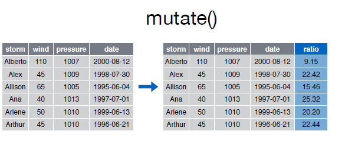

## Exemplo 1

- A altura está em **cm**, eu quero a altura em **metros**.
- Ele vai calcular para cada um, o resultado correspondente.

```r
ebola %>%
  select( ht_cm) %>% # só para simplificar a base
  mutate(ht_m=ht_cm/100)
```

```
# A tibble: 5,888 × 2
   ht_cm  ht_m
   <dbl> <dbl>
 1    48  0.48
 2    59  0.59
 3   238  2.38
 4   135  1.35
 5    71  0.71
 6   116  1.16
 7    87  0.87
 8    11  0.11
 9   226  2.26
10   174  1.74
# ℹ 5,878 more rows
```

## Exemplo 2

- Eu queria a altura em metros para calcular o IMC, posso continuar o cálculo com a nova variável.

```r
ebola %>%
  select(wt_kg, ht_cm) %>%
  mutate(ht_m=ht_cm/100,
         imc=wt_kg/ht_m^2)
```

```
# A tibble: 5,888 × 4
   wt_kg ht_cm  ht_m   imc
   <dbl> <dbl> <dbl> <dbl>
 1    27    48  0.48 117.
 2    25    59  0.59  71.8
 3    91   238  2.38  16.1
 4    41   135  1.35  22.5
 5    36    71  0.71  71.4
 6    56   116  1.16  41.6
 7    47    87  0.87  62.1
 8     0    11  0.11   0
 9    86   226  2.26  16.8
10    69   174  1.74  22.8
# ℹ 5,878 more rows
```

## Exemplo 3

- Fazer o cálculo com os valores de uma coluna só.
- O que acontece?

```r
ebola %>%
  filter(!is.na(age)) %>%
  select(age) %>%
  mutate(idade_media=mean(age)) # ou na.rm=T
```

```
# A tibble: 5,802 × 2
     age idade_media
   <dbl>       <dbl>
 1     2        16.1
 2     3        16.1
 3    56        16.1
 4    18        16.1
 5     3        16.1
 6    16        16.1
 7    16        16.1
 8     0        16.1
 9    61        16.1
10    27        16.1
# ℹ 5,792 more rows
```

## CUIDADO!!

- Ele faz a conta para a **coluna**!
- Fazer a conta para uma linha é meio chato!
  - Não é simples como no excel.
  - Mas, se precisar! Pesquise as funções:
    - **rowwise()**
    - **c_across()**

## As aulas estão mais curtas né?

- Aproveitem para revisar!